# The Outlier Model

Mads Lindskou

# Background Theory on The Outlier Detection Model

### Contingency Tables

The outlier detection model can only be used on discrete data; i.e data for which all variables can only take on a finite set of values (also called *levels*). We also say, that such variables are *discrete variables* or *categorical variables*.

Consider for example the built in discrete data set in `R` on `4526` applicants to graduate school at Berkeley for the six largest departments in 1973 classified by admission and sex. Below, a small sample of the data is seen.

| Admit | Gender | Dept |
| --- | --- | --- |
| Admitted | Male | E |
| Rejected | Male | B |
| Rejected | Female | E |
| Rejected | Male | D |
| Rejected | Female | D |
| Rejected | Female | C |

Another and more appropriate way of showing the entire data, is via a *contingency table* which summarizes the counts of all combinations of `Admit`, `Gender` and `Dept`

|  |  | Dept | A | B | C | D | E | F |
| --- | --- | --- | --- | --- | --- | --- | --- | --- |
| Admit | Gender |  |  |  |  |  |  |  |
| Admitted | Female |  | 89 | 17 | 202 | 131 | 94 | 24 |
|  | Male |  | 512 | 353 | 120 | 138 | 53 | 22 |
| Rejected | Female |  | 19 | 8 | 391 | 244 | 299 | 317 |
|  | Male |  | 313 | 207 | 205 | 279 | 138 | 351 |

This is much more informative and we can e.g. say immediately that `207` `Male` applicants were `Rejected` at department `B`. A particular entry in the table is called a `cell`. So `(Male, Rejected, B)` is a cell with *cellcount* `207`. The *dimension* of the table is the number of variables (here `3`). For high-dimensional tables things get more complicated and it may not be feasible to show the table (think of hundreds of DNA markers) and there may be many cells with zero cellcount.

The outlier detection method (described shortly) uses such contingency table data. However, it should be mentioned one more time, that a contingency table is in one-to-one correspondence with a “regular” discrete data set; contingency tables are nothing more than a convenient way of describing discrete data sets.

### Outliers

An outlier can be regarded as an observation which deviates so much from the other observations in a database as to arouse suspicions that it was generated by a different mechanism. The outlier detection method directly adapts this definition by specifying a hypothesis of an outlier being distributed differently than all other observations in a given database. An outlier is also a very case-specific unit, since it may be interpreted as natural extreme noise in some applications and in other applications it might be the most interesting observation.

For high-dimensional data, it is a tedious task to determine anomalies such as outliers. The method described here is a multivariate method for outlier detection in high-dimensional contingency tables, i.e. data with discrete variables only. The method relies on the class of decomposable graphical models to model the relationship among the variables of interest, which can be depicted by an undirected graph called the interaction graph.

### Decomposable Graphical Models

Consider the undirected graph $G$ in the figure below.

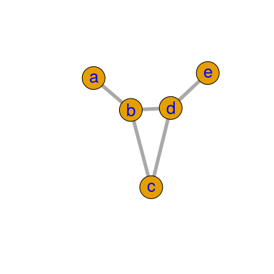

$G$: An undirected decomposable graph.

The set of vertices is $V = \{a,b,c,d,e\}$ and the set of edges is $E = \{ab, bc, bd, cd,de\}$. The cliques are $C_1 = \{a, b\}$, $C_2 = \{b, c, d\}$ and $C_3 = \{d, e\}$. The minimal separators are $S_{2} = \{b\}$ and $S_3 = \{d\}$ where $S_{2}$ separates $C_{1}$ and $C_{2}$ and $S_{3}$ separates $C_{2}$ and $C_{3}$. Since $G$ has no cycles of length greater than three, the graph is decomposable. Notice, that $a$ is only connected to $\{c,d,e\}$ through $\{b\}$; we interpret this as “$a$ is independent of $\{c,d,e\}$ when we know the value of $b$”. Such statements can be used to gain insight into complex structures.

Finally, we can associate a probability measure with an *interaction graph*; an undirected graph with each vertex being a random variable. For decomposable graphs, the probability density function can be written in terms of the cliques and separators. Collectively, models for which the interaction graph is decomposable are called decomposable graphical models (DGM). For more details on graphical models, see for example (Whittaker 2009; Lauritzen 1996).

This setup allow us to estimate probabilities of having a specific combination of associated variables. Think of the vertex set $V = \{a,b,c,d,e\}$ as a set of five variables where each variable can be either zero or one. Then given the decomposable interaction graph $G$ we can, as an example, estimate the probability that $a = 1, b = 0, c = 1, d = 1$ and $e = 0$. In this contrived example there are $2^{5} = 32$ possible combinations.

Tree graphs are per definition decomposable graphs. Notice that the graph $G$ is not a tree because of the presence of the cycle $\{b,c,d\}$. However, the graph is indeed decomposable.

# The Outlier Detection Model

### Toy Example Facilitating Theory

For simplicity, we focus on a single microhaplotype containing $3$ DNA markers which we rename to $X, Y$ and $Z$ to have shorter names.

```r
library(molic)

vars <- structure(tgp_haps[[29]], names = c("X", "Y", "Z"))

df_EUR <- tgp_dat %>%
  filter(pop_meta == "EUR") %>%
  select(!!vars)

df_AFR <- tgp_dat %>%
  filter(pop_meta == "AFR") %>%
  select(!!vars)
```

`molic` has a nice function `sptable` for creating sparse contingency tables. The input is a `matrix`. It is sparse in the sense, that it do not show the combinations with zero counts. The European table is

```r
sptable(as.matrix(df_EUR))
```

```
## X-Y-Z
## -----
## GAA : 125
## GAG : 706
## GGA : 19
## TAG : 156
```

and the African table is

```r
sptable(as.matrix(df_AFR))
```

```
## X-Y-Z
## -----
## GAA : 118
## GAG : 473
## GGA : 708
## TAG : 23
```

From the EUR table we see that only 19 profiles have the combination $(X,Y,Z) = (G,G,A)$ whereas in the AFR table 708 profiles have that combination. Thus, the two populations seems to differ quite substantially.

Our goal is to test a profile in AFR for being an outlier in EUR. The first step is to model the interaction graph for the variables $X, Y$ and $Z$ with a decomposable graph. We use the `efs` function to fit the graph and then plot it.

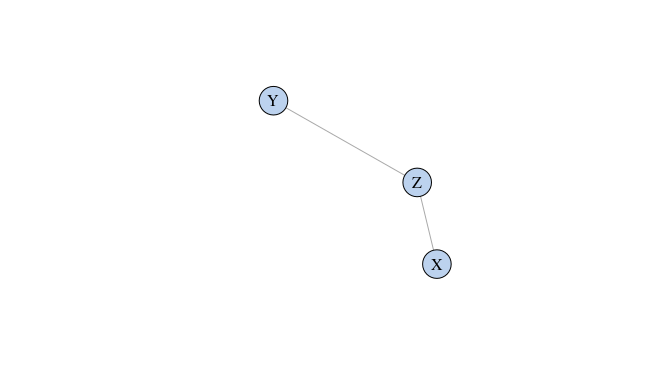

$G$: Interaction graph for EUR.

```r
DG_EUR <- efs(df_EUR, trace = FALSE)
G_adj  <- adj_list(DG_EUR)   # Used for input to the outlier model

set.seed(7)
plot(DG_EUR, vertex.size = 35)
```

Notice that $G$ is in fact a tree (no cycles). The cliques and separator of $G$ are given by
$$C_{1} = \{ X, Z\}, \quad C_{2} = \{Y, Z \} \quad \mbox{and} \quad S = \{ Z \}.$$

and we can now form the *marginal tables*. The marginal table of clique $C_1$ is

```r
sptable(as.matrix(df_EUR[, c("X", "Z")]))
```

```
## X-Z
## ---
## GA : 144
## GG : 706
## TG : 156
```

and for $C_2$

```r
sptable(as.matrix(df_EUR[, c("Y", "Z")]))
```

```
## Y-Z
## ---
## AA : 125
## AG : 862
## GA : 19
```

and for $S$

```r
sptable(as.matrix(df_EUR[, "Z"]))
```

```
## Z
## -
## A : 144
## G : 862
```

We can then count the number of profiles with a specific combination for the cliques and the separator. The number of profiles having the combination $(X, Z) = (G,A)$ for clique $C_1$ is for example $n_{XZ}(G,A) = 144$. The number of profiles having combination $(Y, Z) = (G,A)$ for clique $C_2$ is ${n_{YZ}(G,A) = 19}$ and for the separator the number of profiles with $Z = A$ is $n_Z(A) = 144$. It can be shown that the *joint probability* of having the combination $(X, Y, Z) = (G, G, A)$ is given by

$$\begin{equation*}
\frac{n_{XZ}(G,A) \cdot n_{YZ}(G,A) }{ 1006 \cdot n_{Z}(A) } = \frac{ 144 \cdot 19 }{ 1006 \cdot 144} = 0.0188867,
\end{equation*}$$

where 1006 is the total number of profiles in `df_EUR`.

In other words, with low probability Europeans have the specific combination $(X,Y,Z) = (G, G, A)$ for this specific microhap under the model. If a new observed profile, say $z_{new}$, have this combination for the selected microhap it supports the belief that this profile might not originate from Europe. We can carry out the same calculations for all microhaps and combine the result into a *likelihood* $L_0$ that expresses how likely it is that $z_{new}$ originates from Europe. We can also specify an alternative likelihood, $L_{1}$, specifying how likely it is that $z_{new}$ do not originate from Europe. We then define the *likelihood ratio* as

$$\begin{equation*}
\label{eq:LR}
LR = \frac{L_{0}}{L_{1}},
\end{equation*}$$

which can be shown to be completely specified through the counts of profiles in cliques and separators for the given interaction graph. We can therefore test if $z_{new}$ is an outlier in Europe by calculating $LR$ and determine if the value of $LR$ (soon we modify $LR$ and call it *deviance*) is “too large” in which case we would reject that $z_{new}$ originates from Europe.

Under the null hypothesis, $z_{new}$ belongs to the hypothesised data base (EUR in this case) and so we append the profile to `df_EUR`. Assume $z_{new}$ is the $7'$th profile from AFR.

```r
z_new <- unlist(df_AFR[7, ]) # It is important to unlist here!
df_EUR_z_new <- df_EUR %>%
  bind_rows(z_new)
```

Lets see what the specific value of $z_{new}$ is

```r
unname(z_new)
```

```
## [1] "G" "G" "A"
```

So we already have an idea, that $z_{new}$ could be an outlier in `df_EUR`. All ingredients are now given in order to make the outlier test.

```r
set.seed(7)
om <- as.matrix(df_EUR_z_new) %>%
  outlier_model(G_adj, nsim = 10000)
```

What we have done is, that we have simulated $10000$ profiles from `df_EUR_7` and for each of those simulations we can calculate $LR$. In effect, we obtain an estimated *distribution* of $LR$. More precise we get the distribution of $-2\cdot \log LR$ which is called the *deviance*. We can plot the distribution of the deviance as

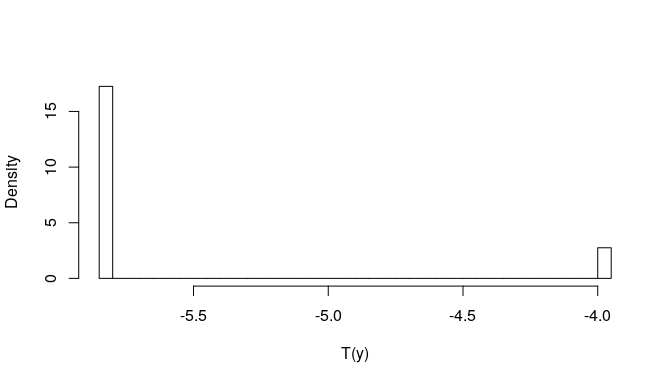

```r
pmf(om)
```

Since we only have $3$ variables it looks a bit odd. However, the particular deviance score for $z_{new}$ is given by

```r
deviance(om, z_new)
```

```
## [1] -3.970305
```

with p-value for $z_{new}$ being an outlier in EUR

```r
p_val(om, deviance(om, z_new))
```

```
## [1] 0
```

Therefore we declare $z_{new}$ as an outlier in EUR on a significance level $\alpha = 0.05$.

### A Larger Example

In this example we include more variables from `tgp_dat` and show how to aggregate decomposable graphs using expert knowledge. We know, that the SNP variables are *independent* between microhaplotypes. We include the first $25$ microhaplotypes which consists of $96$ SNP variables.

```r
microhaps <- tgp_haps[1:25]
vars   <- unname(unlist(microhaps))

df_EUR_micro <- tgp_dat %>%
  filter(pop_meta == "EUR") %>%
  select(vars)

df_AFR_micro <- tgp_dat %>%
  filter(pop_meta == "AFR") %>%
  select(!!vars)
```

Then we fit an interaction graph on each microhaplotype

```r
micro_graphs <- lapply(microhaps, function(x) {
  df_x <- df_EUR_micro[, x]
  efs(df_x, trace = FALSE)
})
```

Then we extract the graphs and “aggregate” them (more precisely we take the union of the graphs)

```r
G_union <- micro_graphs %>%
  unname() %>%
  lapply(function(x) adj_list(x)) %>%
  unlist(recursive = FALSE)
```

Plotting the fitted interaction graph

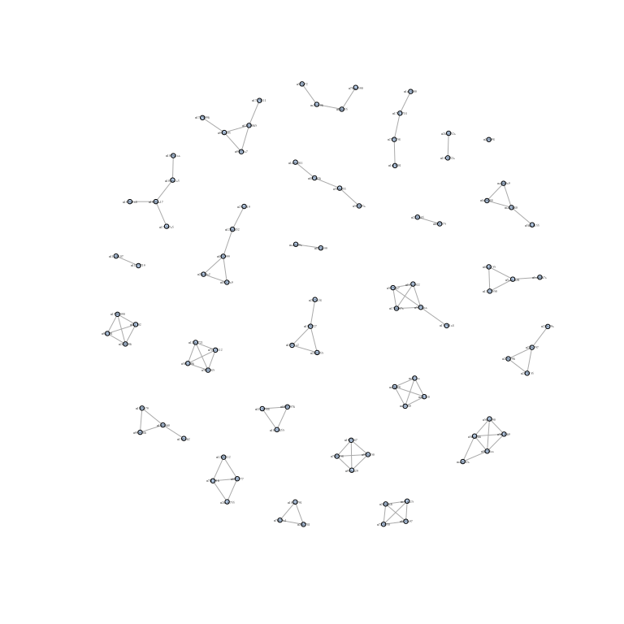

```r
# Cheating a little so we can plot the graph
x <- list(G_A = as_adj_mat(G_union)) # The plot function just needs the "G_A" argument
class(x) <- c(class(x), "efs")
plot(x, vertex.size = 2, vertex.label.cex = 0.2)
```

Constructing the outlier model where we first append the hypothesized outlier from AFR

```r
set.seed(7)
z_new <- unlist(df_AFR_micro[7, ]) # It is important to unlist here!

df_EUR_micro_z_new <- df_EUR_micro %>%
  bind_rows(z_new)

om_micro <- as.matrix(df_EUR_micro_z_new) %>%
  outlier_model(G_union, nsim = 10000)

# print model info
om_micro
```

```
##
##  ----------------------
##   Simulations: 10000
##   Variables: 96
##   Observations: 1007
##   Estimated mean: -166.35
##   Estimated variance: 13.25
##   <outlier_model>
##  ----------------------
```

Plotting the distribution of the deviance

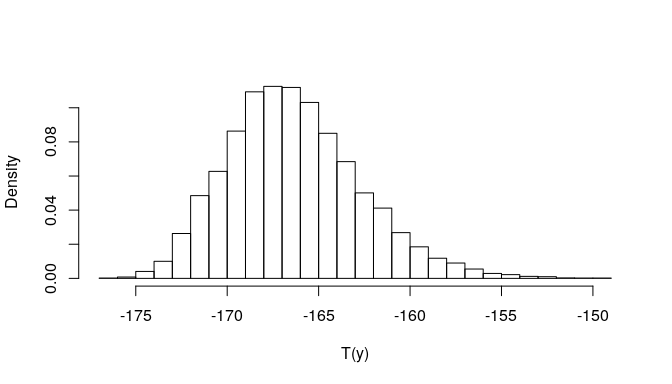

```r
pmf(om_micro)
```

Determine if $z_{new}$ is an outlier

```r
dz_new <- deviance(om_micro, z_new)
dz_new
```

```
## [1] -137.3278
```

```r
p_val(om_micro, dz_new)
```

```
## [1] 0
```

It is seen again, that $z_{new}$ does not belong to `df_EUR` with a very high degree of certainty at a significance level of $0.05$.

# References

Consortium, 1000 Genomes Project, and others. 2015. “A Global Reference for Human Genetic Variation.” *Nature* 526 (7571). Nature Publishing Group: 68.

Lauritzen, Steffen L. 1996. *Graphical Models*. Vol. 17. Clarendon Press.

Whittaker, Joe. 2009. *Graphical Models in Applied Multivariate Statistics*. Wiley Publishing.